# Sentimentanalyse mit Twitter-Daten

Gruppe6

2020-05-20

# Laden der gereinigten Tweets

Zunächst laden die Twitter-Datensätze, die am häufigsten retweeted wurden.

```r
tlkeywords <- c("tweets_corona_en.csv")

tweets <- read_csv(tlkeywords,locale = locale(encoding = "UTF-8")) %>%
             select(kategorie,
                    screen_name,
                    datum,
                    jahr,
                    monat,
                    text)
## Parsed with column specification:
## cols(
##   kategorie = col_character(),
##   screen_name = col_character(),
##   datum = col_date(format = ""),
##   jahr = col_double(),
##   monat = col_double(),
##   text = col_character(),
##   lang = col_character()
## )
```

```r
head(tweets)
```

```
## # A tibble: 6 x 6
##   kategorie  screen_name  datum       jahr monat text
##   <chr>      <chr>        <date>     <dbl> <dbl> <chr>
## 1 politik    EU_Health    2020-05-14  2020     5 rt speaking to ercd the c~
## 2 politik    UN           2020-05-14  2020     5 rt we join and in calling~
## 3 non-profi~ UNICEF       2020-05-14  2020     5 sharon helps her little b~
## 4 gesundheit WHO          2020-05-14  2020     5 covid is already having a~
## 5 gesundheit WHO_Europe   2020-05-14  2020     5 press conference on covid~
## 6 journalis~ washingtonp~ 2020-05-14  2020     5 abbott coronavirus test m~
```

# Erstellung eines Sentiment-Lexikons

In einem zweiten Schritt lesen wir mit der Funktion *scan()* das *Bing Liu Sentiment Lexikon* in R ein.

```r
positive.woerter.bl <- scan("lexika/bingliu-positive-words.txt", what = "char", sep = "\n", skip = 35, quiet = T)
negative.woerter.bl <- scan("lexika/bingliu-negative-words.txt", what = "char", sep = "\n", skip = 35, quiet = T)
```

Weitere mit der Funktion *dictionary()* erstellen wir das nötige Sentiment-Lexikon für die Sentimentanalyse.

```r
sentiment.lexikon <- dictionary(list(positive = positive.woerter.bl, negative = negative.woerter.bl))
str(sentiment.lexikon)
## Formal class 'dictionary2' [package "quanteda"] with 2 slots
##   ..@ .Data:List of 2
##   .. ..$ :List of 1
##   .. .. ..$ : chr [1:2006] "a+" "abound" "abounds" "abundance" ...
##   .. ..$ :List of 1
##   .. .. ..$ : chr [1:4783] "2-faced" "2-faces" "abnormal" "abolish" ...
##   ..@ meta :List of 3
##   .. ..$ system:List of 5
##   .. .. ..$ package-version:Classes 'package_version', 'numeric_version'  hidden list of 1
##   .. .. .. ..$ : int [1:3] 2 0 1
##   .. .. ..$ r-version      :Classes 'R_system_version', 'package_version', 'numeric_version'  hidden list of 1
##   .. .. .. ..$ : int [1:3] 3 6 1
##   .. .. ..$ system         : Named chr [1:3] "Windows" "x86-64" "xfpxxfp"
##   .. .. .. ..- attr(*, "names")= chr [1:3] "sysname" "machine" "user"
##   .. .. ..$ directory      : chr "D:/Studium/01_UNI OS/4. Semester/Applied Analytics"
##   .. .. ..$ created        : Date[1:1], format: "2020-05-20"
##   .. ..$ object:List of 2
##   .. .. ..$ valuetype: chr "glob"
##   .. .. ..$ separator: chr " "
##   .. ..$ user  : list()
```

Die Kategorien, die Tweets der Twitter-Datensätze haben, werden als keywords gespeichert.

```r
keywords <- c("politik",
              "gesundheit",
              "unternehmen",
              "non-profits",
              "journalismus",
              "bildung",
              "sonstige"
              )
```

# Verrechnung der Sentiment-Scores für die Kategorien

## Absolute Wortfrequenzen

1. Die Sentimentanalyse wird für die Kategorien mithilfe des For-Schleifs durchgeführt.
2. Importierte Twitter-Datensätze sollten zuerst in das Dateformat *Korpus* konvertiert werden.
3. Wir erstellen eine DFM für jeden der Kategorien mithilfe *corpus_subset* und wenden das Sentiment-Lexikon an.
4. Die Twitter-Datensätze jeder Kategorie werden anschließend mit Hilfe des Arguments groups nach Monat und Jahr aggregiert.
5. Anschließend erstellen wir mittels convert einen data frame, welchen wir noch etwas bearbeiten, um ihn besser plotten zu können.

```r
korpus <- corpus(tweets)

for (i in 1:length(keywords)) {

  korpus.kate <- corpus_subset(korpus, kategorie ==  keywords[i])
  meine.dfm.kate <- dfm(korpus.kate, groups = c("monat", "jahr"),
                        dictionary = sentiment.lexikon)

  sentiment.kate <- convert(meine.dfm.kate, "data.frame") %>%
  gather(positive, negative, key = "Polarität", value = "Wörter") %>%
  mutate(Datum = as.Date(paste("01", document, sep = "."), "%d.%m.%Y"))


  picture <- sentiment.kate  %>%
    ggplot(aes(Datum, Wörter, colour = Polarität, group = Polarität)) +
    geom_line(size = 1) + scale_colour_brewer(palette = "Set1") +
    scale_x_date(date_breaks = "1 month", date_labels = "%b %Y") +
    ggtitle(keywords[i]) +
    xlab("") +
    theme(axis.text.x = element_text(angle = 45, hjust = 1))

  print(ggplotly(picture))

}
```

[output not shown]

## Relative Wortfrequenzen

Hier werden die Tweets aus den ausgewählten Kategorien im direkten Vergleich.

```r
fkeywords <- c("politik",
              "gesundheit",
              "unternehmen",
              "non-profits",
              "journalismus",
              "bildung"
              #"sonstige"
              )
```

1. Zuerst sollen wir auch die Sentimentanalyse für die absoluten Wortfrequenzen durchführen.
2. Weitere berechnen wir die Gewichtung von Sentiment-Scores mit der Funktion *dfm_weight()*.
3. Die positive und negative Sentiment-Anteile werden anschließend verrechnet und skaliert.
4. Am Ende vergleichen die Sentiment-Scores der Kategorien.

```r
  korpus.kategorien <- corpus_subset(korpus, kategorie ==  "politik")
  meine.dfm.kategorien <- dfm(korpus.kategorien, groups = c("monat", "jahr"),
                             dictionary = sentiment.lexikon)

  meine.dfm.kategorien.prop <- dfm_weight(meine.dfm.kategorien, scheme = "prop")
  sentiment.kategorien.prop <- convert(meine.dfm.kategorien.prop, "data.frame") %>%
    gather(positive, negative, key = "Polarität", value = "Sentiment") %>%
    mutate(Datum = as.Date(paste("01", document, sep = "."), "%d.%m.%Y")) %>%
    mutate(kategorie = "politik")

print(paste("Finished categorie", 1, "of", length(fkeywords), sep=" "))
```

```
## [1] "Finished categorie 1 of 6"
```

```r
for (i in 2:length(fkeywords)) {

  korpus.kategorie <- corpus_subset(korpus, kategorie ==  fkeywords[i])
  meine.dfm.kategorie <- dfm(korpus.kategorie, groups = c("monat", "jahr"),
                              dictionary = sentiment.lexikon)

  meine.dfm.kategorie.prop <- dfm_weight(meine.dfm.kategorie, scheme = "prop")
  sentiment.kategorie.prop <- convert(meine.dfm.kategorie.prop, "data.frame") %>%
  gather(positive, negative, key = "Polarität", value = "Sentiment") %>%
  mutate(Datum = as.Date(paste("01", document, sep = "."), "%d.%m.%Y")) %>%
  mutate(kategorie = fkeywords[i])

  sentiment.kategorien.prop <- bind_rows(sentiment.kategorie.prop,
                                         sentiment.kategorien.prop)

   print(paste("Finished account", i, "of", length(fkeywords), sep=" "))

}
```

```
## [1] "Finished account 2 of 6"
## [1] "Finished account 3 of 6"
## [1] "Finished account 4 of 6"
## [1] "Finished account 5 of 6"
## [1] "Finished account 6 of 6"
```

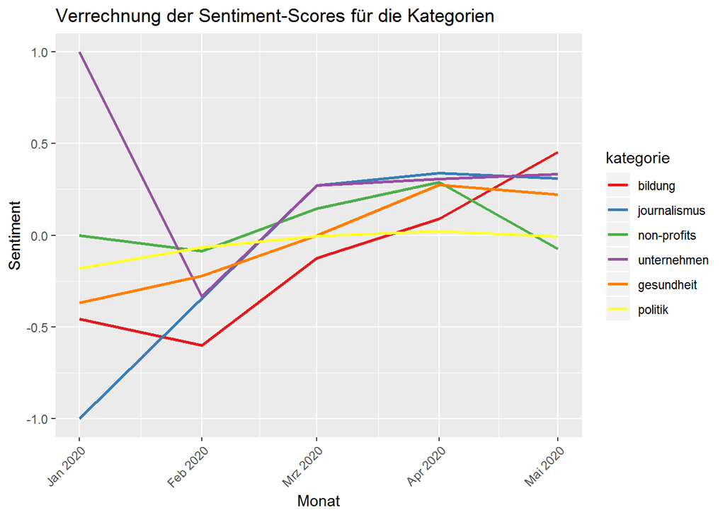

```r
 sentiment.to <- sentiment.kategorien.prop %>%
                 filter(Polarität == "positive") %>%
                 select(Datum, kategorie, Sentiment)

# OPTIMIEREN
sentiment.to$Sentiment <- rescale(sentiment.to$Sentiment, to = c(-1,1))
sentiment.to$kategorie <- as_factor(sentiment.to$kategorie)
#picturest <-  sentiment.to %>%
              ggplot(sentiment.to,aes(Datum, Sentiment, colour = kategorie, group = kategorie)) +
                  geom_line(size = 1) +
                  scale_colour_brewer(palette = "Set1") +
                  scale_x_date(date_breaks = "1 month", date_labels = "%b %Y") +
                  theme(axis.text.x = element_text(angle = 45, hjust = 1)) +
                  ggtitle("Verrechnung der Sentiment-Scores für die Kategorien") +
                  xlab("Monat")
```

```r
#print(ggplotly(picturest))
```

# Anzeigen det Sentiment mit hervorgehobenen positiven / negativen Sätzen

Möglicherweise kann man die Funktion *sentiment_by()* benutzt, um die Ausgabe der Sentiment zeilenweise mit hervorgehobenen positiven / negativen Sätzen zu sehen. Die Hervorhebungsfunktion bricht eine sentiment_by-Ausgabe um, um eine hervorgehobene HTML-Datei zu erzeugen (positiv = grün; negativ = pink). Mit dieser HTML-Datei werden die Tweets detailliert analysiert.

```r
for (i in 1:length(keywords)) {

  tweets_highlight <- tweets %>%
                      filter(kategorie == keywords[i]) %>%
                      select(screen_name,text) %>%
                      unique()

  tweet_sentiment_highlight <- get_sentences(tweets_highlight$text) %>%
                     sentiment_by()

   sentimentr::highlight(tweet_sentiment_highlight, file =
                           file.path(paste("Sentimenthighlight_",
                                            keywords[i],"_polarity.html",sep="")),
                                            open = FALSE, digits = 3)

   print(paste("Finished", i, "of", length(keywords), sep=" "))


}
## Saved in Sentimenthighlight_politik_polarity.html
## [1] "Finished 1 of 7"
## Saved in Sentimenthighlight_gesundheit_polarity.html
## [1] "Finished 2 of 7"
## Saved in Sentimenthighlight_unternehmen_polarity.html
## [1] "Finished 3 of 7"
## Saved in Sentimenthighlight_non-profits_polarity.html
## [1] "Finished 4 of 7"
## Saved in Sentimenthighlight_journalismus_polarity.html
## [1] "Finished 5 of 7"
## Saved in Sentimenthighlight_bildung_polarity.html
## [1] "Finished 6 of 7"
## Saved in Sentimenthighlight_sonstige_polarity.html
## [1] "Finished 7 of 7"
```